# DV_RProject3

Natasha Halfin, Evan Johnston, Kaylyn Zvonek

For this project, we used a dataset containing information on the climates in major US cities including Nashville, Austin, and Seattle.

```r
library("ggplot2")
library("gplots")
library("bitops")
library("knitr")
library("jsonlite")
library("ggthemes")
library("RCurl")
library("reshape2")
library("tidyr")
library("dplyr")
library("grid")
```

```r
source("../01 Data/climate_data.R")
source("../02 Data Wrangling/data_wranglings1.R")
```

These are our 3 climate tables from data on Austin, Nashville, and Seattle.

We chose these 3 cities because its interesting to know about local weather and at least one of us has lived in each city. Additionally, each city exhibits unique weather patterns, so we thought it would be insightful to compare each city across a few variables.

We added 2 columns to our data frames: Season and City. Season is based on the date column and City is based on the table name.

The value -9999 represents a null value.

```r
data.frame(head(austin_data))
```

```
##             STATION         STATION_NAME ELEVATION LATITUDE LONGITUDE
## 1 GHCND:US1TXTV0086 AUSTIN 4.7 NNE TX US     230.1  30.3734  -97.7328
## 2 GHCND:US1TXTV0086 AUSTIN 4.7 NNE TX US     230.1  30.3734  -97.7328
## 3 GHCND:US1TXTV0086 AUSTIN 4.7 NNE TX US     230.1  30.3734  -97.7328
## 4 GHCND:US1TXTV0086 AUSTIN 4.7 NNE TX US     230.1  30.3734  -97.7328
## 5 GHCND:US1TXTV0086 AUSTIN 4.7 NNE TX US     230.1  30.3734  -97.7328
## 6 GHCND:US1TXTV0087 AUSTIN 3.9 NNE TX US     229.2  30.3574  -97.7235
##   DATE_YMD  MDPR PRCP  SNWD  SNOW  TMAX  TMIN   CITY SEASON
## 1 20130526 -9999  160 -9999 -9999 -9999 -9999 Austin Spring
## 2 20130530 -9999    5 -9999 -9999 -9999 -9999 Austin Spring
## 3 20130602 -9999   28 -9999 -9999 -9999 -9999 Austin Spring
## 4 20130610 -9999  102 -9999 -9999 -9999 -9999 Austin Spring
## 5 20130619 -9999  180 -9999 -9999 -9999 -9999 Austin Spring
## 6 20130320 -9999   41 -9999 -9999 -9999 -9999 Austin Spring
```

```r
data.frame(head(nash_data))
```

```
##             STATION         STATION_NAME ELEVATION LATITUDE LONGITUDE
## 1 GHCND:US1TNDV0081 ANTIOCH 4.3ENE TN US     167.9  36.0818  -86.5969
## 2 GHCND:US1TNDV0081 ANTIOCH 4.3ENE TN US     167.9  36.0818  -86.5969
## 3 GHCND:US1TNDV0081 ANTIOCH 4.3ENE TN US     167.9  36.0818  -86.5969
## 4 GHCND:US1TNDV0081 ANTIOCH 4.3ENE TN US     167.9  36.0818  -86.5969
## 5 GHCND:US1TNDV0081 ANTIOCH 4.3ENE TN US     167.9  36.0818  -86.5969
## 6 GHCND:US1TNDV0081 ANTIOCH 4.3ENE TN US     167.9  36.0818  -86.5969
##   DATE_YMD  MDPR PRCP  SNWD SNOW  TMAX  TMIN      CITY SEASON
## 1 20130320 -9999    0 -9999    0 -9999 -9999 Nashville Spring
## 2 20130321 -9999    0 -9999    0 -9999 -9999 Nashville Spring
## 3 20130322 -9999    0     0    0 -9999 -9999 Nashville Spring
## 4 20130323 -9999    8     0    0 -9999 -9999 Nashville Spring
## 5 20130324 -9999   56     0    0 -9999 -9999 Nashville Spring
## 6 20130325 -9999    0 -9999    0 -9999 -9999 Nashville Spring
```

```r
data.frame(head(seat_data))
```

```
##             STATION          STATION_NAME ELEVATION LATITUDE LONGITUDE
## 1 GHCND:US1WAKG0154 REDMOND 6.2 ESE WA US     176.2  47.6406 -121.9912
## 2 GHCND:US1WAKG0154 REDMOND 6.2 ESE WA US     176.2  47.6406 -121.9912
## 3 GHCND:US1WAKG0154 REDMOND 6.2 ESE WA US     176.2  47.6406 -121.9912
## 4 GHCND:US1WAKG0154 REDMOND 6.2 ESE WA US     176.2  47.6406 -121.9912
## 5 GHCND:US1WAKG0154 REDMOND 6.2 ESE WA US     176.2  47.6406 -121.9912
## 6 GHCND:US1WAKG0154 REDMOND 6.2 ESE WA US     176.2  47.6406 -121.9912
##   DATE_YMD  MDPR PRCP  SNWD  SNOW  TMAX  TMIN    CITY SEASON
## 1 20130501 -9999    0 -9999 -9999 -9999 -9999 Seattle Spring
## 2 20130502 -9999    0 -9999     0 -9999 -9999 Seattle Spring
## 3 20130503 -9999    0 -9999     0 -9999 -9999 Seattle Spring
## 4 20130504 -9999    0 -9999     0 -9999 -9999 Seattle Spring
## 5 20130505 -9999    0 -9999     0 -9999 -9999 Seattle Spring
## 6 20130506 -9999    0 -9999     0 -9999 -9999 Seattle Spring
```

Here is our data dictionary which explains our climate codes.

PRCP= Precipitation  
SNOW = Snowfall  
SNWD = Snow depth  
TMAX = Maximum temperature  
TMIN = Minimum temperature

We filtered by dates in each table to create the season variable values. Then we bound the new rows to the season column in each table.

This allowed us to create an inner join that finds the average precipitation by Season of each city.

```r
data.frame(SEASON_InnerJoin)
```

```
##   SEASON austinPRCP nashPRCP seatPRCP
## 1   Fall   45.63377 32.73068 30.88228
## 2 Spring   33.52659 52.75607 27.67828
## 3 Summer   30.82154 49.07124 16.74549
## 4 Winter   17.75989 49.65719 29.34439
```

This inner joined dataframe displays the max precipitation of each city by date with a join on date.

```r
data.frame(head(prcp_InnerJoin))
```

```
##   DATE_YMD austPrcp nashPrcp seatPrcp
## 1 20130101      145      132        8
## 2 20130102        5      104       51
## 3 20130103        0        0       48
## 4 20130104       46        0      142
## 5 20130105       81        0       33
## 6 20130106        0        5      130
```

This left outer join finds the min and max recorded temperatures for Seattle and Nashville by date.

```r
data.frame(head(nash_seatTEMP))
```

```
##   DATE_YMD seatMinTemp seatMaxTemp nashMinTemp nashMaxTemp
## 1 20130101           0          67          11          61
## 2 20130102         -17          83         -11          61
## 3 20130103         -22          89         -33          56
## 4 20130104          22         111         -44          72
## 5 20130105          44          89         -11          83
## 6 20130106          39          89          11         111
```

**Data Visualizations**

```r
source("../03 Visualizations/practice_viz.R")
```

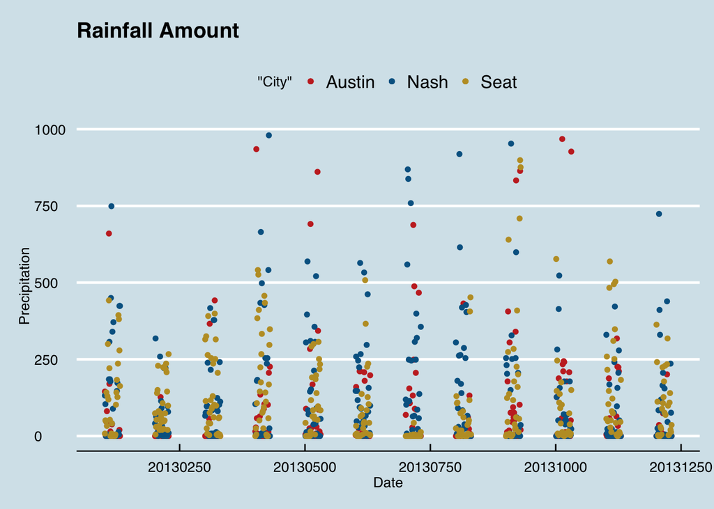

```r
plot(g1)
```

**Maximum and Minimum Temperature by Date and City** This plot shows the distribution of maximum and minimum temperatures by city throughout the span of the year. There are clear trends for which city exhibits more extreme temperatures, but it is interesting to note that occasionally Nashville exhibits lower minimum temperatures than Seattle.

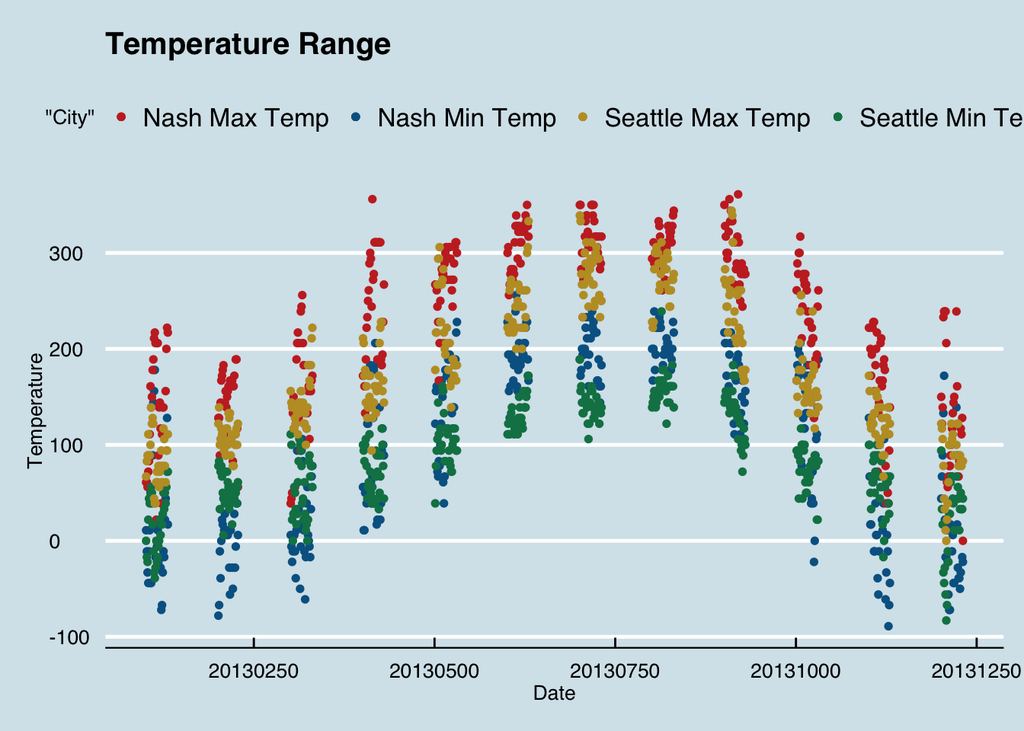

```r
plot(g2)
```

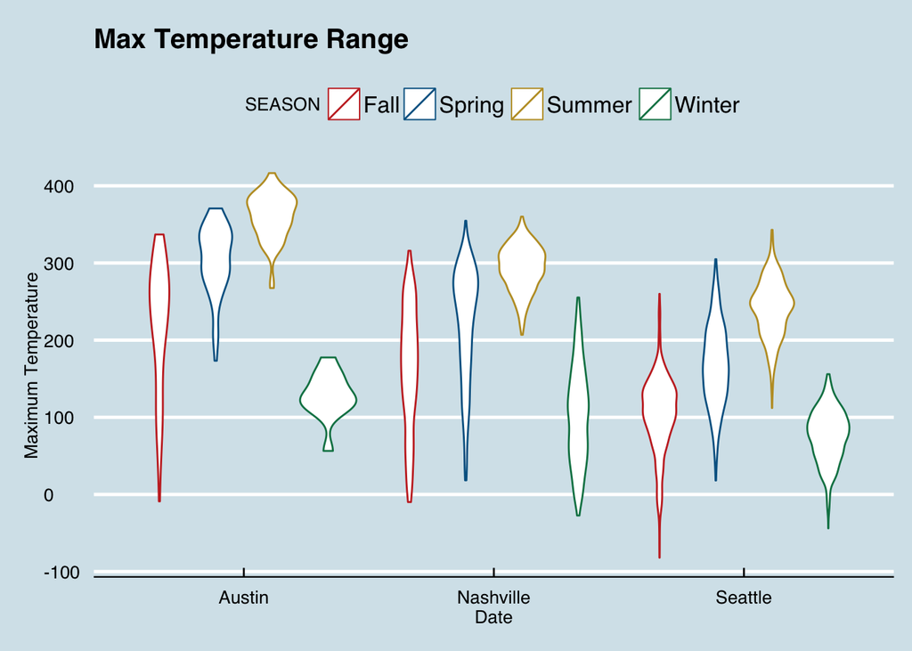

```r
plot(g4,vp=viewport(layout.pos.row=2,layout.pos.col=1))
```

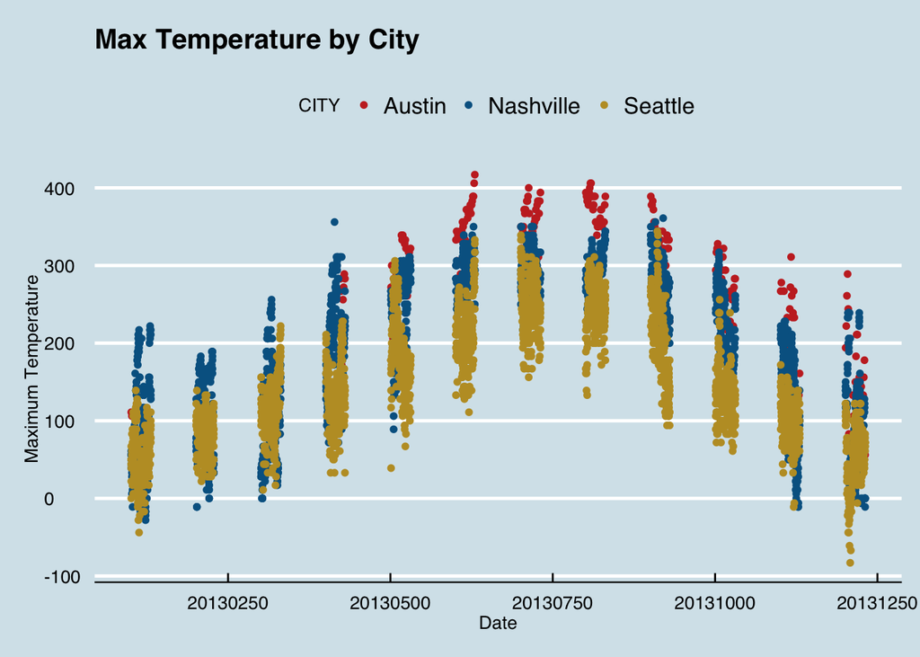

```r
plot(g3,vp=viewport(layout.pos.row=1,layout.pos.col=1))
```

**Categorical Visualizations**

[figure not shown]

**Non-Categorical Visualizations**

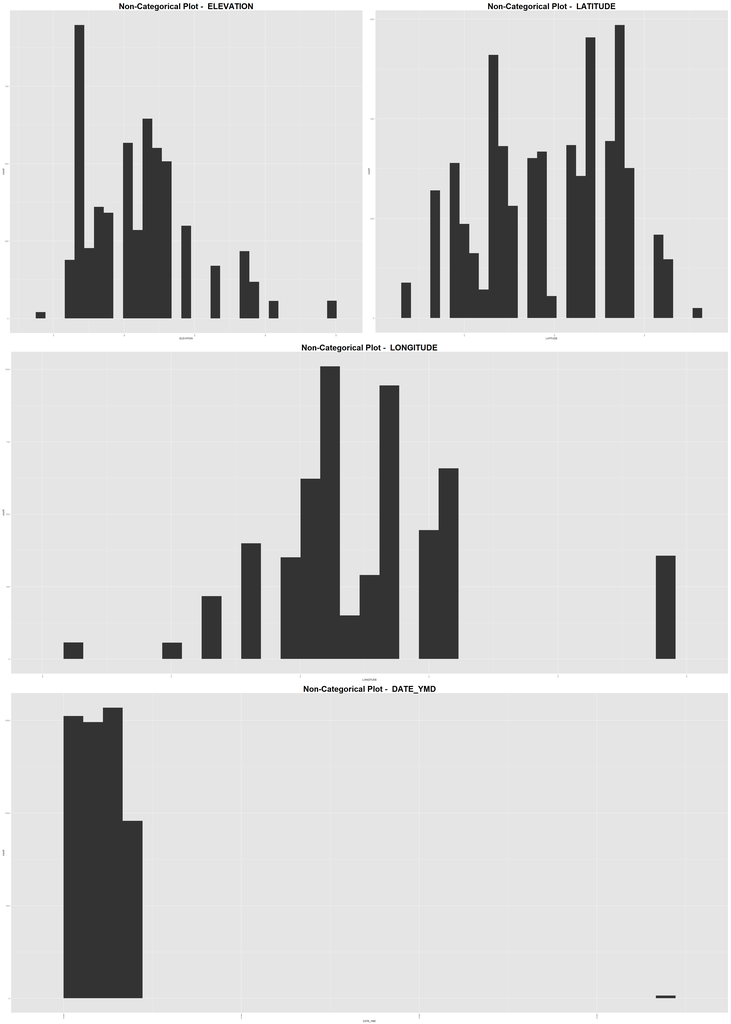